# Microbiome_analysis_notes

[figure not shown]

Fallstudie

Bio Data Science, 2025  
Agnes Grünfelder, Milica Krunic, Dmitrij Turaev

## Overview: targeted vs. shotgun metagenomics

This lecture covers some key topics and practical considerations for amplicon data analysis. Due to time constraints, this is a selective overview and not a comprehensive guide.

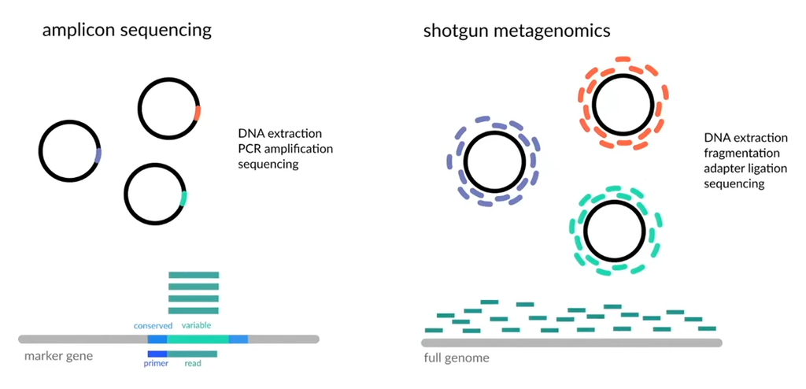

Amplicon sequencing vs. shotgun metagenomics

(source: [youtube](https://www.youtube.com/watch?v=W94rHJ6KcTQ))

## Targeted and shotgun metagenomics have different goals

Sample collection and DNA isolation are common steps in targeted and shotgun metagenomics. Data analysis differs for targeted and untargeted approaches:

- Targeted approaches rely on amplicon-based pipelines involving clustering into OTUs/ASVs and reference database matching
- Shotgun methods employ assembly, binning, and metagenome-assembled genome (MAG) reconstruction alongside tools for gene prediction and pathway analysis

[figure not shown]

[Targeted amplicon vs metagenomic sequencing approaches](https://academic.oup.com/bib/article/22/1/178/5678919?login=false)

A schematic overview demonstrating diverse sample types, commonly utilized sequencing platforms and systematic and stepwise data processing steps. (Bharti and Grimm 2021)

- Targeted metagenomics focuses on specific genomic regions (often, but not always, 16S rRNA gene), to perform taxonomic profiling and community diversity assessment with high sensitivity for known organisms (primer design is based on organisms represented in reference databases)
- Shotgun metagenomics sequences all DNA in a sample randomly, which allows functional gene annotation, strain-level resolution (with high enough coverage), and discovery of novel microbes or viruses

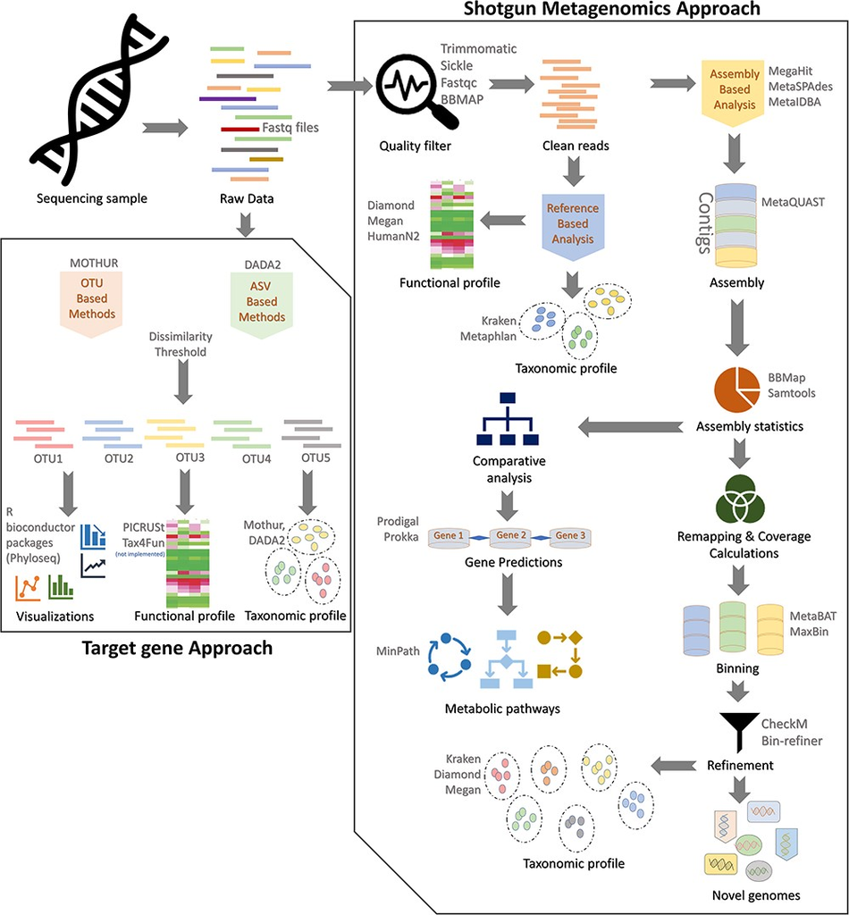

[Targeted amplicon vs metagenomic sequencing approaches](https://academic.oup.com/bib/article/22/1/178/5678919?login=false)

Protocol for the acquisition and analysis of targeted amplicon and shotgun metagenomics data from sequencing to functional annotation. It shows the basic flow of experimental steps followed by downstream preprocessing and analysis steps, and mentions popular tools. (Bharti and Grimm 2021)

## Amplicon analysis requires clustering or denoising

This is necessary, because PCR amplification introduces errors that artificially inflate the number of unique sequences, making it necessary to distinguish true biological variation from technical artifacts.

The key difference is that amplicon sequencing involves multiple rounds of PCR amplification of the target gene, which accumulates errors, while shotgun metagenomics typically involves no PCR amplification before sequencing.

[figure not shown]

[Workflow of commonly used methods for amplicon (A) and metagenomic (B) sequencing](https://www.ncbi.nlm.nih.gov/pmc/articles/PMC8106563/)

Blue, orange, and green blocks represent input, intermediate, and output files, respectively. The text next to the arrow represents the method, with frequently used software shown in parentheses. Taxonomic and functional tables are collectively referred to as feature tables. (Liu et al. 2021)

## 16S rRNA is a universal and highly conserved gene

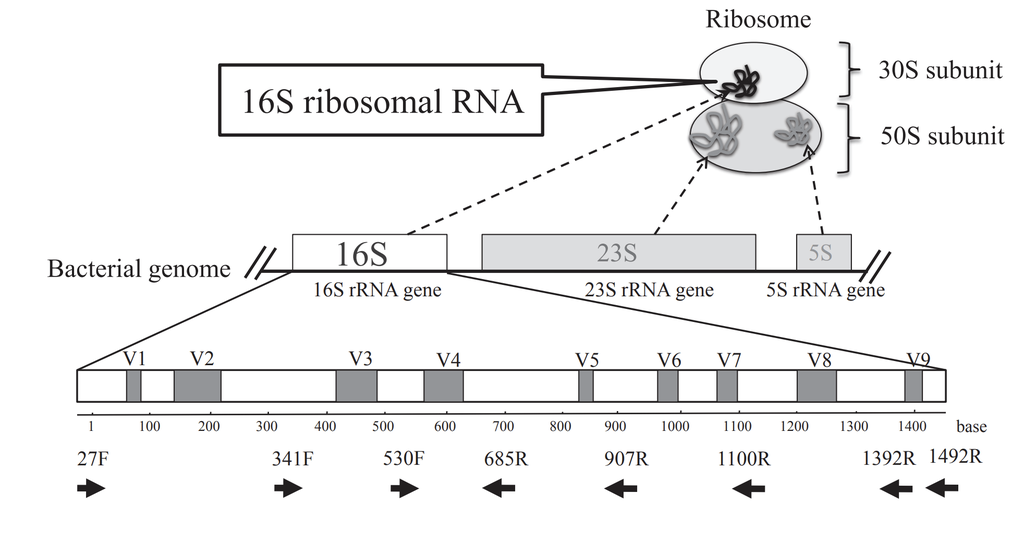

[The schema of ribosome complex and 16S rRNA gene](https://bioinformatics.ccr.cancer.gov/docs/qiime2/Lesson2/)

Grey boxes indicate hypervariable regions, interspersed between conserved regions (in white). The bold arrows show approximate positions of universal primers on 16S rRNA gene sequence of Escherichia coli. ([Fukuda et al. 2016](https://www.jstage.jst.go.jp/article/juoeh/38/3/38_223/_article))

- 16S rRNA highly conserved among bacteria and archaea → Molecular clock to infer phylogenetic relationships ([Tsukuda 2017](https://www.nature.com/articles/s41598-017-10214-3))
  - However, the phylogenetic signal is less reliable than previously thought ([Hassler 2022](https://pmc.ncbi.nlm.nih.gov/articles/PMC9264627/))
- Taxonomy based on 16S rRNA very popular, databases are growing
- Classification resolution up to species or genus level, also depends on sequencing length and region
- Primer selection? → needs to be evaluated also dependent on the community
- Multiple copies per genome, intragenomic variation possible

### Varying 16S rRNA gene copy numbers

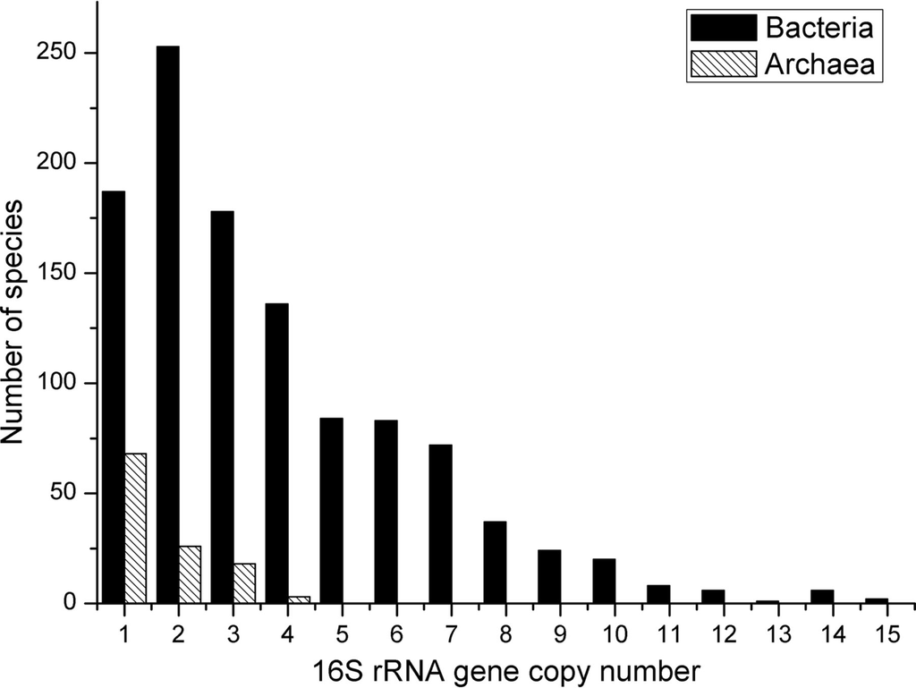

[Distribution of different 16S rRNA gene copy numbers among bacteria and archaea.](https://journals.asm.org/doi/10.1128/aem.01282-13)

> Several tools have recently been developed for predicting 16S gene copy numbers (GCNs) using phylogenetic methods and based on sequenced genomes, in order to correct for these biases. ... Here, we systematically evaluate the predictability of 16S GCNs across bacterial and archaeal clades, based on ∼ 6,800 public sequenced genomes and using several phylogenetic methods. Further, we assess the accuracy of GCNs predicted by three recently published tools ([PICRUSt](https://picrust.github.io/picrust/tutorials/algorithm_description.html#copy-number-normalization), [CopyRighter](https://microbiomejournal.biomedcentral.com/articles/10.1186/2049-2618-2-11), and [PAPRICA](https://github.com/bowmanjeffs/paprica)) ... We recommend against correcting for 16S GCNs in microbiome surveys by default, unless OTUs are sufficiently closely related to sequenced genomes or unless a need for true OTU proportions warrants the additional noise introduced, so that community profiles remain interpretable and comparable between studies. ("Correcting for 16S rRNA gene copy numbers in microbiome surveys remains an unsolved problem", [Louca et al. 2018](https://microbiomejournal.biomedcentral.com/articles/10.1186/s40168-018-0420-9))

> On the other hand, we found that GCN variation has limited impacts on beta-diversity analyses such as PCoA, NMDS, PERMANOVA and random-forest test. ("Accounting for 16S rRNA copy number prediction uncertainty and its implications in bacterial diversity analyses", [Gao and Wu 2023](https://www.nature.com/articles/s43705-023-00266-0))

Additional links:

- [qiime2 forum: copy number variation picrust](https://forum.qiime2.org/t/copy-number-variation-q2-picrust2/19547/)
- Identifying biases and their potential solutions in human microbiome studies. [Nearing and Comeau 2021](https://microbiomejournal.biomedcentral.com/articles/10.1186/s40168-021-01059-0)

### Heterogeneity of 16S rRNA genes

> Heterogeneity of 16S rRNA genes was detected in 952 out of 2,011 genomes (585 out of 1,212 species) from which 16S rRNA genes were retrieved. A majority of the heterogeneity detected was below 1% (833 out of 952 genomes), but for the remaining 119 genomes with intragenomic heterogeneity greater than 1%, classification to a different species using 16S rRNA-based methods may occur. ("Intragenomic Heterogeneity of 16S rRNA Genes Causes Overestimation of Prokaryotic Diversity", [Sun et al. 2013](https://journals.asm.org/doi/10.1128/aem.01282-13))

> Only a minority of bacterial genomes harbors identical 16S rRNA gene copies, and sequence diversity increases with increasing copy numbers. While certain taxa harbor dissimilar 16S rRNA genes, others contain sequences common to multiple species. ("The Variability of the 16S rRNA Gene in Bacterial Genomes and Its Consequences for Bacterial Community Analyses", [Větrovský and Baldrian 2013](https://pmc.ncbi.nlm.nih.gov/articles/PMC3583900/))

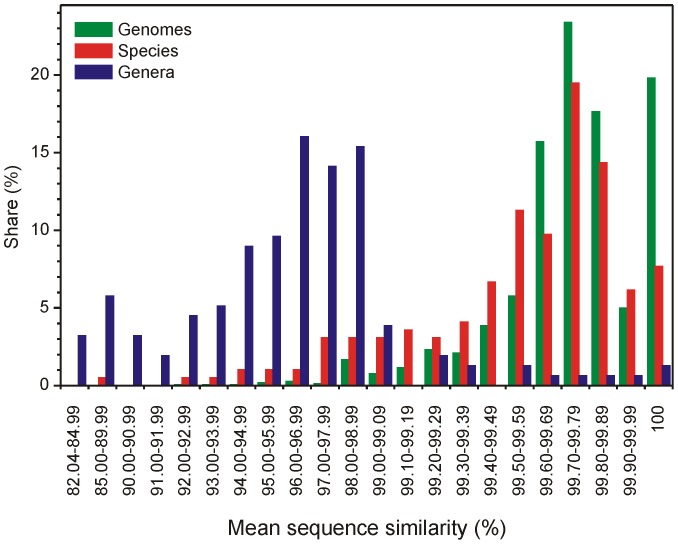

[Mean pairwise sequence similarity of 16S rRNA sequences.](https://pmc.ncbi.nlm.nih.gov/articles/PMC3583900/)

Similarity within bacterial genomes, among genomes belonging to the same species and among species belonging to the same genus. Phylogenetically, Firmicutes and Gammaproteobacteria showed high 16S rRNA within-genome variability, while Alphaproteobacteria and Chlamydiae showed low variability; the differences were statistically significant. The level of dissimilarity within a genome can be relatively high: fourteen genomes from this dataset contained at least one pair of 16S rRNA sequences with a similarity below 97%. ([Větrovský and Baldrian 2013](https://pmc.ncbi.nlm.nih.gov/articles/PMC3583900/))

### Resolution of 16S rRNA for taxonomic assignment

> 16S rRNA gene sequencing ... has low phylogenetic power at the species level and poor discriminatory power for some genera, and DNA relatedness studies are necessary to provide absolute resolution to these taxonomic problems. The genus Bacillus is a good example of this. For example, B. globisporus and B. psychrophilus share >99.5% sequence similarity with regard to their 16S rRNA genes, and yet at the DNA level exhibit only 23 to 50% relatedness in reciprocal hybridization reactions. Similarly, different Edwardsiella species exhibit 99.35 to 99.81% similarity to each other, and yet these three species are clearly distinguishable biochemically and by DNA homology (28 to 50% relatedness). Such examples indicate that SSU sequence similarity even to a very high level does not in each case imply identity or accuracy in microbial identifications. ("16S rRNA Gene Sequencing for Bacterial Identification in the Diagnostic Laboratory: Pluses, Perils, and Pitfalls", [Janda and Abbott 2007](https://pmc.ncbi.nlm.nih.gov/articles/PMC2045242/))

> We demonstrate that targeting of 16S variable regions with short-read sequencing platforms cannot achieve the taxonomic resolution afforded by sequencing the entire (~1500 bp) gene. We further demonstrate that full-length sequencing platforms are sufficiently accurate to resolve subtle nucleotide substitutions (but not insertions/deletions) that exist between intragenomic copies of the 16S gene. ... [Sequencing] full-length 16S intragenomic copy variants has the potential to provide taxonomic resolution of bacterial communities at species and strain level. ("Evaluation of 16S rRNA gene sequencing for species and strain-level microbiome analysis", [Johnson et al. 2019](https://www.nature.com/articles/s41467-019-13036-1))

> The choice of the targeted variable region might affect the outcome of the microbiome studies. In our in silico analysis, we have evaluated whether the targeted variable region has an impact on taxonomic resolution in 16 plant-related microbial genera. Through a comparison of 16S rRNA gene variable regions with whole-genome data, our findings suggest that the V1–V3 region is generally a more suitable option than the widely used V3–V4 region for targeting microbiome analysis in plant-related genera. However, sole reliance on one region could introduce detection biases for specific genera. Thus, we are suggesting that while transitioning to full-length 16S rRNA gene and whole-genome sequencing for plant-microbiome analysis, the usage of genus-specific variable regions can achieve more precise taxonomic assignments. ("Taxonomic resolution of different 16S rRNA variable regions varies strongly across plant-associated bacteria", [Hrovat et al. 2024](https://pmc.ncbi.nlm.nih.gov/articles/PMC10980831/))

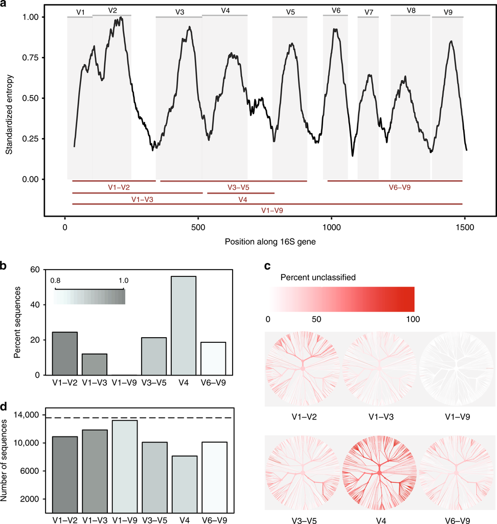

[In-silico comparison of 16S rRNA variable regions.](https://www.nature.com/articles/s41467-019-13036-1)

**a** Shannon entropy across the 16S gene based on the alignment of a single representative sequence for each known species present in the Greengenes database. Sequences were aligned against a single reference 16S gene for E. coli K-12. Gray panels depict variable regions defined by commonly used primer-binding sites. Variable regions considered in this study are shown as red lines (bottom). **b** Proportion of sequences for each variable region that could not be identified to species level when classifying each sequence against the reference database from which it was derived at a confidence threshold of 80% (RDP classifier). **c** Trees based on taxonomy of sequences present in the in-silico database. The same tree is provided for each variable region. The color of each branch reflects the proportion of sequences within each clade that could not be identified to species level. **d** The number of OTUs created when clustering sequences for each variable region at 99% sequence similarity. Dashed line indicates the number of unique sequences (>1% different) in the original database. Note that the dataset was generated in silico from a set of non-redundant (i.e., > 1% different), full-length 16S sequences from a public database (Greengenes). ([Johnson et al. 2019](https://www.nature.com/articles/s41467-019-13036-1))

## OTU clustering vs. ASV denoising

**PCR amplification introduces errors** that artificially inflate the number of unique sequences. To distinguish such technical artifacts from true biological variation, amplicon analysis requires clustering or denoising.

1. In the **OTU approach**, sequences are clustered into groups based on a similarity threshold (typically 97%), and each group is represented by a single consensus sequence (the centroid or representative sequence):

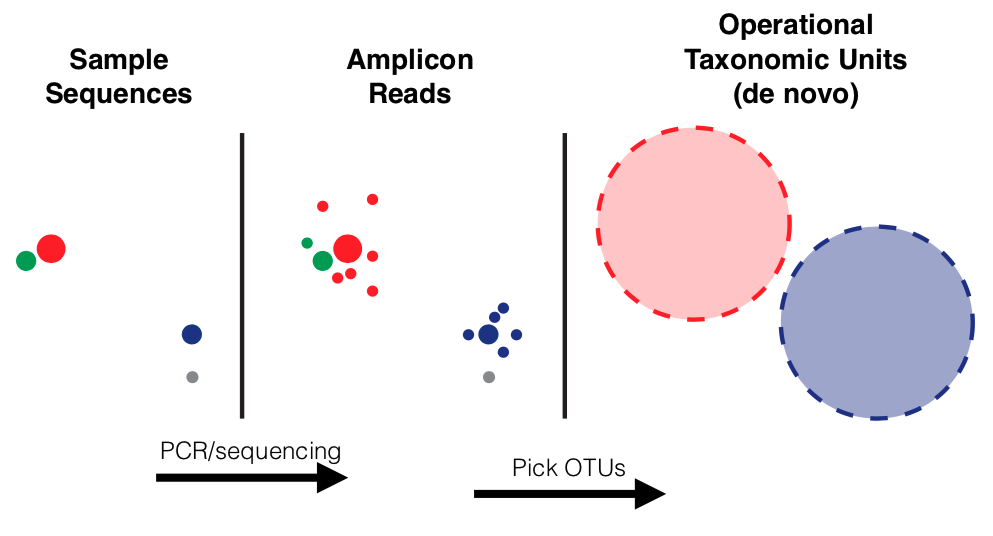

[OTUs are clustered by similarity cutoff](https://en.wikipedia.org/wiki/Amplicon_sequence_variant)

Clustering may accidentally group two biologically distinct DNA sequences into the same unit. The "perfect" result in this example should identify four sequences (colors), while the actual result has only two. (based on [Callahan et al. 2016](https://www.nature.com/articles/nmeth.3869#Sec20), supplementary information)

1. **ASV methods** use statistical models to identify and remove sequences that are likely to be errors (based on their abundance patterns and quality scores), retaining only sequences that are likely to represent true biological variants:

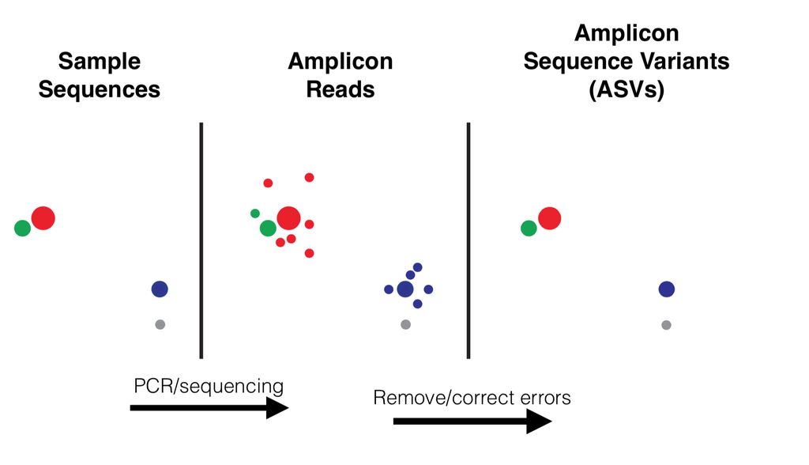

[ASVs are identified by statistics/probability](https://en.wikipedia.org/wiki/Amplicon_sequence_variant)

ASV selection considers the error probability and the frequency of reads. If a sequence is too abundant for it to be explained by sequencing error, it's identified as an ASV.

Among the first publications that suggested an alternative to OTU clustering were [Eren et al. 2011](https://journals.plos.org/plosone/article?id=10.1371/journal.pone.0026732) and [Eren et al. 2013](https://besjournals.onlinelibrary.wiley.com/doi/10.1111/2041-210X.12114). They developed a concept they called "oligotyping" that was based on "the entropy analysis of variable sites in sequences". They motivated this approach with the fact that "clustering approaches ... often fail to resolve ecologically meaningful differences between closely related organisms in complex microbial data sets".

The ASV approach was popularized in the [DADA2 publication](https://www.nature.com/articles/nmeth.3869) (with >31k citations as of 10/2025). In a short opinion paper, its authors said that ASVs should replace OTUs altogether:

> We argue that the improvements in reusability, reproducibility and comprehensiveness are sufficiently great that ASVs should replace OTUs as the standard unit of marker-gene analysis and reporting ([Callahan et al. 2017](https://academic.oup.com/ismej/article/11/12/2639/7537828))

Many studies compared ASV- with OTU-based approaches. Some studies found that they give comparable results:

> Despite quantitative differences in microbial richness, we found that all α and β diversity metrics were highly positively correlated (r > 0.90) between samples analyzed with both approaches. Moreover, the community composition of the dominant taxa did not vary between approaches. Consequently, statistical inferences were nearly indistinguishable. ... We conclude that for broadscale (e.g., all bacteria or all fungi) α and β diversity analyses, ASV or OTU methods will often reveal similar ecological results. Thus, while there are good reasons to employ ASVs, we need not question the validity of results based on OTUs. ([Glassman and Martiny 2018](https://pmc.ncbi.nlm.nih.gov/articles/PMC6052340/))

Others found clear discrepancies:

> The choice of the pipeline significantly influenced alpha and beta diversities and changed the ecological signal detected, especially on presence/absence indices such as the richness index and unweighted Unifrac. ... The identification of major classes and genera also revealed significant discrepancies across pipelines. ([Chiarello et al. 2022](https://journals.plos.org/plosone/article?id=10.1371/journal.pone.0264443))

Most studies find that ASVs are generally more reliable:

> Two levels of progressive OTUs clustering, (99% and 97%) were compared with the ASV data. The results showed that the OTUs clustering proportionally led to a marked underestimation of the ecological indicators values for species diversity and to a distorted behaviour of the dominance and evenness indexes with respect to the direct use of the ASV data. ... Overall, data support the view that reference-based OTU clustering carries several misleading disadvantageous biases, including the risk of missing novel taxa which are yet unreferenced in databases. ([Fasolo et al. 2024](https://journals.plos.org/plosone/article?id=10.1371/journal.pone.0309065))

> OTU-level USEARCH-UPARSE and MOTHUR performed well, but with lower specificity than ASV-level pipelines. ([Prodan et al. 2020](https://journals.plos.org/plosone/article?id=10.1371/journal.pone.0227434))

The actual algorithms used for OTU clustering and ASV identification also play a role:

> ASV algorithms—led by DADA2— resulted in having a consistent output, yet suffered from over-splitting, while OTU algorithms—led by UPARSE—achieved clusters with lower errors, yet with more over-merging. Notably, UPARSE and DADA2 showed the closest resemblance to the intended microbial community, especially when considering measures for alpha and beta diversity. ([Fares et al. 2025](https://environmentalmicrobiome.biomedcentral.com/articles/10.1186/s40793-025-00705-6))

However, even the author of the UPARSE algorithm now considers [OTU clustering obsolete](https://drive5.com/usearch/manual/cmd_cluster_otus.html#:~:text=For%20most%20purposes,for%20further%20discussions.) for most purposes. Here is what the [Qiime docs](https://amplicon-docs.qiime2.org/en/latest/explanations/conceptual-overview.html#conceptual-overview-denoising-and-clustering:~:text=Clustering%20methods%20produce,out%20an%20alternative.) say on this topic:

> Clustering methods produce lower-resolution features than the newer denoising/ASV-based approaches. We recommend against using clustering, but we provide the functionality because there are some cases where it is still relevant.

OTU clustering is still widely used, however ASVs are conceptually more sound, and will probably replace OTUs long-term. Currently, the choice of using ASVs or OTUs largely depends on your research questions; both may be appropriate for different aspects of your research.

## Biases and errors in amplicon studies

Why is OTU clustering or ASV denoising even necessary?

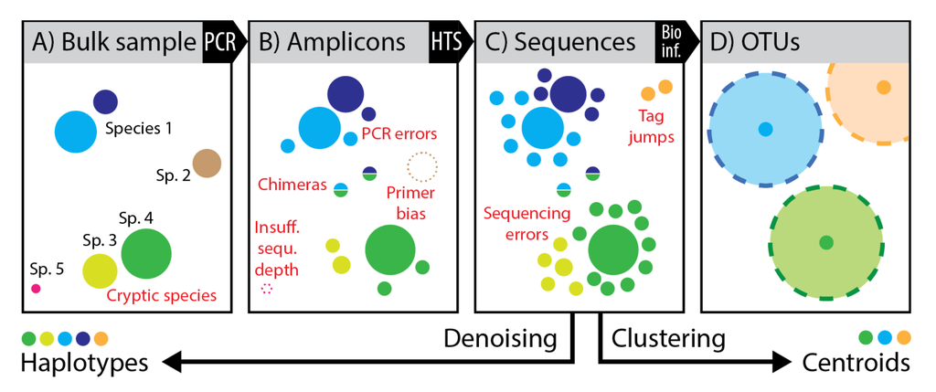

[Multiple key biases can affect sequence accuracy](https://pmc.ncbi.nlm.nih.gov/articles/instance/5896493/bin/peerj-06-4644-s001.pdf)

PCR amplification can skew sequence abundance, fail to amplify taxa due to primer bias or insufficient sequencing depth in the case of underrepresented/rare taxa. Sequencing can generate new false sequence variants due to sequencing errors, chimera formation and mixing of multiplexed samples. The impact of these errors is usually reduced by strict quality filtering and clustering of similar sequences into operational taxonomic units (OTUs). Normally, only the most abundant sequence in an OTU is considered and used to identify the respective species, which in turn means that information on genetic diversity is lost. Recently, alternative denoising strategies have been developed to remove sequences affected by errors from a dataset and retain the actual haplotype sequences present in a sample. ([Elbrecht 2018](https://peerj.com/articles/4644/))

### Biases: an overview

#### Biological

- Genomic 16S rRNA copy number variation ([Louca et al. 2018](https://microbiomejournal.biomedcentral.com/articles/10.1186/s40168-018-0420-9))
- Intragenomic variation ([Větrovský and Baldrian 2013](https://pmc.ncbi.nlm.nih.gov/articles/PMC3583900/))
- Primer/gene choice (e.g. [Kameoka et al. 2021](https://bmcgenomics.biomedcentral.com/articles/10.1186/s12864-021-07746-4), [Jay & Inskeep 2015](https://pmc.ncbi.nlm.nih.gov/articles/PMC4496867/))

#### Sample preparation

- Sample storage conditions, DNA degradation/fragmentation
- Differences in DNA extraction efficiency (different taxa have different cell wall structures)
- Contamination (reagent/lab contamination, especially important for low-biomass samples)

#### PCR-related

- PCR bias
  - Primer mismatch bias (most prominent in early cycles of PCR; [Schaffer et al. 2025](https://onlinelibrary.wiley.com/doi/10.1111/1755-0998.14119#:~:text=1.1.2%20Amplification%20Efficiency))
  - Non-primer-mismatch bias (mid-to-late cycle PCR reactions), e.g. due to GC content or amplicon length -> it's preferable to compare samples with the same number of PCR cycles ([Silverman et al. 2021](https://pmc.ncbi.nlm.nih.gov/articles/PMC8284789/))
- Polymerase base substitution errors ([Potapov and Ong 2017](https://journals.plos.org/plosone/article?id=10.1371/journal.pone.0169774))
- Tag jumping ([Rodriguez-Martinez et al. 2022](https://onlinelibrary.wiley.com/doi/10.1111/1755-0998.13745))
- Chimera formation ([Qin et al. 2023](https://journals.asm.org/doi/10.1128/msystems.01025-23))

#### Sequencing

- Sequencing errors
- Index hopping ([Jia et al. 2022](https://environmentalmicrobiome.biomedcentral.com/articles/10.1186/s40793-022-00436-y), [revvity.com](https://www.revvity.com/at-en/blog/index-hopping-illumina-ngs-what-it-why-it-matters-and-how-unique-dual-indexing-solves-problem))
- Sequencing depth bias ([Wen et al. 2017](https://journals.plos.org/plosone/article?id=10.1371/journal.pone.0176716), [Ramakodi 2021](https://link.springer.com/article/10.1007/s00284-021-02345-8), [Dully et al. 2021](https://www.sciencedirect.com/science/article/pii/S2001037021001148))

#### Computational

- Parameter choices (e.g. filtering and OTU clustering thresholds), denoising/error correction algorithm choice, rarefaction/normalization choice, positive/negative control handling
- Database incompleteness/errors (for taxonomic assignment)
- Batch effects (when comparing across runs/studies)
- Algorithm choices, e.g. [Nearing et al. 2022](https://www.nature.com/articles/s41467-022-28034-z), [Calgaro et al. 2020](https://pmc.ncbi.nlm.nih.gov/articles/PMC7398076/)

## OTU picking

OTU picking means clustering sequences to collapse similar sequences (e.g., those that are ≥ 97% similar to each other) into OTUs. This was once a common approach, used to dereplicate identical sequences and perform a sort of quick-and-dirty denoising procedure "to capture stochastic sequencing and PCR errors, which should be rare and similar to more abundant centroid sequences" ([amplicon-docs.qiime2.org](https://amplicon-docs.qiime2.org/en/latest/explanations/conceptual-overview.html#conceptual-overview-denoising-and-clustering)).

OTU picking methods can be categorized as ([Wei et al. 2021](https://www.frontiersin.org/journals/microbiology/articles/10.3389/fmicb.2021.644012/full)):

- **Closed-reference clustering**: Compares each query sequence to an annotated reference taxonomy database; sequences matched to the same reference sequence are grouped into the same OTU. This approach doesn't work well for novel organisms.
- **De novo clustering** (also called taxonomy independent): All sequences are clustered into OTUs based on the pairwise sequence distances rather than comparing against a reference database. Different clustering methods can be used: hierarchical clustering, heuristic clustering, model-based, or network-based clustering.
- **Open-reference clustering**: Combination of the closed-reference and de novo method; a closed-reference clustering approach is first used to assign OTUs, and the unassigned sequences are then grouped by a de novo clustering method.

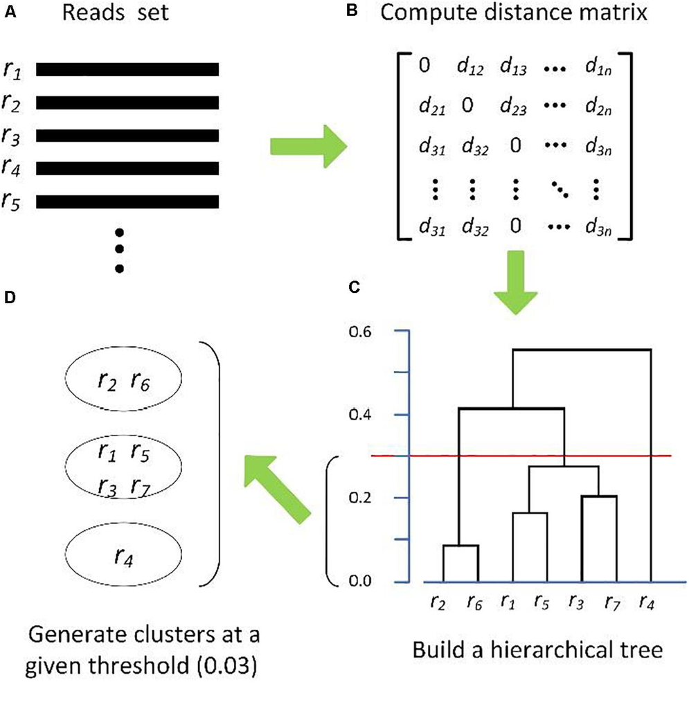

[Hierarchical de-novo clustering methods are based on a distance matrix](https://www.frontiersin.org/journals/microbiology/articles/10.3389/fmicb.2021.644012/full)

By applying a predefined clustering threshold to the hierarchical tree, sequences within the threshold are grouped into one OTU.

## DADA2 denoising algorithm

The ASV approach tries to answer this question for each sequence $i$: Does amplicon sequence $i$ originate from sequence $j$ due to sequencing errors?

- **Null hypothesis**: The number of amplicon reads (the abundance) of sequence $i$ is consistent with the error model.
- **Approach**: A $p$-value quantifies the probability that sequence $i$ is too abundant to be explained by sequencing errors. It is calculated based on a Poisson model that reflects the expected number of reads with sequencing errors given a particular error model (probability of sequencing error per position, quality score and nucleotide mismatch). A low $p$ indicates that there are more reads of sequence $i$ than can be explained by errors.
1. First, a sequence alignments between all reads is performed (with two additional heuristics to prevent alignment between sequences that are too dissimilar anyway).
2. DADA2 depends on a parameterized error model. For example, $p(A→C, 35)$ is the probability that an adenine (A) at a particular position in a read is misread as a cytosine (C) when the sequencing quality score is 35. This matrix has 16 possible nucleotide transitions (A→A, A→C, A→G, A→T, etc.) across [41 quality scores](https://help.basespace.illumina.com/files-used-by-basespace/quality-scores). Each element $p(X→Y, q)$ in this matrix represents the probability of a base $X$ being read as $Y$ at a specific quality score $q$ (16 × 41 transition probabilities). The error model quantifies the **rate** $\lambda_{ji}$ at which a read with sequence $i$ is produced from a read with sequence $j$ (as a function of sequence composition and quality).

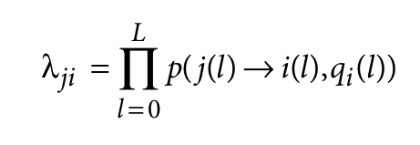

[Error model](https://www.ncbi.nlm.nih.gov/pmc/articles/PMC4927377/)

DADA2 models errors as occurring independently within a read, and independently between reads. Under this model, the rate at which an amplicon read with sequence $i$ is produced from sample sequence $j$ is reduced to the product over the transition probabilities between the $L$ aligned nucleotides.

**DADA2 divisive partitioning algorithm**

1. Dereplication (clustering at 100% identity)
2. All remaining (i.e., unique) sequences are placed into a single partition. The most abundant sequence is assigned as the center of that partition.
3. All sequences are then compared to the center of their partition, error rates are calculated, and the "abundance p-value" is calculated for each sequence. This $p$-value quantifies the probability that sequence is too abundant for it to be explained by sequencing error.
4. If the smallest $p$-value falls below some threshold OMEGA_A, a new partition is formed with the unique sequence with the smallest $p$-value as its center, and all sequences are compared to the center of that new partition.
5. Every sequence joins the partition most likely to have produced it (i.e., the partition that produces the highest expected number of that sequence).
6. Next algorithm iteration, continues with step 3. The division continues until all abundance $p$-values are greater than the threshold OMEGA_A, i.e. all unique sequences are consistent with being produced by amplicon sequencing the center of their partition.
7. The inferred composition of the sample is then the set of central sequences and the corresponding total abundances of those partitions. In other words, each read is denoised by replacing it with the central sequence of its partition.

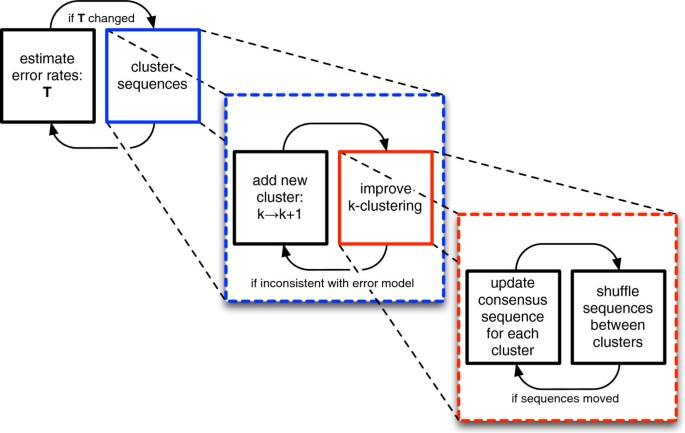

[Basic structure of DADA algorithm](https://bmcbioinformatics.biomedcentral.com/articles/10.1186/1471-2105-13-283)

Denoising PCR-amplified metagenome data. [Rosen et al. 2012](https://bmcbioinformatics.biomedcentral.com/articles/10.1186/1471-2105-13-283)

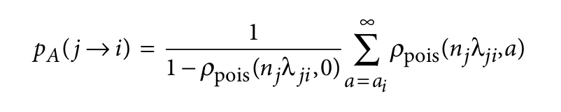

[The abundance p-value](https://www.ncbi.nlm.nih.gov/pmc/articles/PMC4927377/)

The abundance $p$-value quantifies the probability that sequence $i$ is too abundant to be explained by sequencing errors. But what is our expectation regarding the abundance of reads with sequence $i$? If sequencing errors are independent across reads, the number of amplicon reads with sequence $i$ that will be produced from sample sequence $j$ is **Poisson distributed** with expectation equal to an error rate $λ_{ji}$ multiplied by the expected reads of sample sequence $j$. Let unique sequence $i$ with abundance $a_i$ be in partition $j$ containing $n_j$ reads. Then, conditional on $i$ being read at least once, the abundance $p$-value is the probability of seeing that many or more identical reads.

- $λ_{ji}$ - probability that read with sequence $i$ is produced from read with sequence $j$ by sequencing errors
- $n_j$ - number of reads in partition $j$
- $a_i$ - abundance of read with sequence $i$
- $ρ_{pois}$ - Poisson density function

### How does DADA2 estimate the error model parameters?

- DADA2 algorithm uses parametric error model, and can estimate error model parameters (populate the matrix) from the data. This allows to tailor the error model to the specific dataset. Given an inferred partition of the amplicon sequences, DADA2 records the mismatches between every sequence and the center of its partition and counts each type of mismatch (for example, the number of A→C mismatches where Q = 35). The resulting table of observed mismatches represents the errors inferred by DADA2 and can be used to estimate the parameters of the error model.
- DADA2 alternates inference of sample composition (conditional on the parameters of the error model) with parameter estimation of the error rates (conditional on the inferred sample composition) until they converge on a jointly consistent solution, at which point jointly consistent estimates of the error parameters and sample composition are reported.

### There are other algorithms that produce ASVs

- ASVs (amplicon sequence variants) are also referred to as exact sequence variants (ESVs, see [GitHub](https://github.com/benjjneb/dada2/issues/709)), zero-radius OTUs (ZOTUs) by [UNOISE](https://drive5.com/usearch/manual/unoise_algo.html), sub-OTUs (sOTUs) by [deblur](https://journals.asm.org/doi/10.1128/msystems.00191-16), haplotypes ("a set of DNA variants along a single chromosome that tend to be inherited together", e.g. [Couton et al. 2021](https://onlinelibrary.wiley.com/doi/full/10.1002/ece3.7453)), or oligotypes (see [GitHub](https://github.com/benjjneb/dada2/issues/62)) -> **representative sequence**
- What about intraspecific variation?
- What about rare sequence variants?

"DADA2 relies on repeated observations of a sequence to distinguish biological variants from sequencing error. Thus, in order to identify a biological variant, there must be at least 2 error-free reads of that sequence variant present in the data, with more required if the variant is close to another sample sequence. Given a sequencing depth D, and a fraction of error-free sequences f (this varies greatly, but f ∼ 0.5 is not uncommon for Illumina Miseq 2x250 forward reads), DADA2 will not effectively identify variants with frequencies at or below 2/Df, as such variants are unlikely to produce at least two error-free reads." (Callan et al. 2016, [supplementary material](https://static-content.springer.com/esm/art%3A10.1038%2Fnmeth.3869/MediaObjects/41592_2016_BFnmeth3869_MOESM269_ESM.pdf))

Important outcomes:

- feature table (OTU / ASV count data)
- feature data (representative sequences)

## References

**ASVs vs. OTUs**

- The unresolved struggle of 16S rRNA amplicon sequencing: a benchmarking analysis of clustering and denoising methods. [Fares et al., Environ. microbiome 2025](https://environmentalmicrobiome.biomedcentral.com/articles/10.1186/s40793-025-00705-6)
- ASV vs OTUs clustering: Effects on alpha, beta, and gamma diversities in microbiome metabarcoding studies. [Fasolo et al., PLoS One 2024](https://journals.plos.org/plosone/article?id=10.1371/journal.pone.0309065)
- Comparing bioinformatic pipelines for microbial 16S rRNA amplicon sequencing. [Prodan et al. 2020](https://journals.plos.org/plosone/article?id=10.1371/journal.pone.0227434)
- Ranking the biases: The choice of OTUs vs. ASVs in 16S rRNA amplicon data analysis has stronger effects on diversity measures than rarefaction and OTU identity threshold. [Chiarello et al., PLOS One 2022](https://journals.plos.org/plosone/article?id=10.1371/journal.pone.0264443).
- Broadscale Ecological Patterns Are Robust to Use of Exact Sequence Variants versus Operational Taxonomic Units. [Glassman and Martiny, mSphere 2018](https://pmc.ncbi.nlm.nih.gov/articles/PMC6052340/)
- Exact sequence variants should replace operational taxonomic units in marker-gene data analysis. [Callahan et al., ISME 2017](https://academic.oup.com/ismej/article/11/12/2639/7537828)

**PCR Bias**

[figure not shown]